# Analyses for Figure 3

### Analyzing simulated landscapes with the first three models

This function takes a quoted model name (`"cov"`, `"rosalia"`, or `"partial"`) and applies the corresponding function above to all the matrices in the `fakedata` folder.

It returns a data frame with information about each species pair’s simulated landscape, the “true” interaction strength between the pair, and a “predicted” value from the fitted model.

```r
library(parallel)
fit_model = function(method_name, csv_names){
  fit = get(paste("fit", method_name, sep = "_"))
  out_list = mclapply(
    csv_names,
    function(x){
      file_info = as.integer(strsplit(x, "-|\\.csv")[[1]])

      full_path = paste0("fakedata/matrices/", x)

      truth = read.table(
        paste0(
          "fakedata/truths/",
          paste(file_info, collapse = "-"),
          ".txt"
        )
      )

      data.frame(
        n_spp = file_info[1],
        n_loc = file_info[2],
        n_rep = file_info[3],
        truth = unlist(truth),
        predicted = fit(as.matrix(read.csv(full_path, row.names = 1))),
        method = method_name,
        stringsAsFactors = FALSE
      )
    }
  )
  do.call(rbind, out_list)
}
```

```r
cov_results = fit_model("cov", dir("fakedata/matrices"))
```

```r
partial_results = fit_model("partial", dir("fakedata/matrices"))
```

```r
rosalia_results = fit_model("rosalia", dir("fakedata/matrices"))
```

## Settings for fitting a Pairs model

The Pairs program, written by Dr. Werner Ulrich, can be downloaded from [his web site](http://www.keib.umk.pl/pairs/?lang=en) as a Windows executable, but no source code or scripts are available to include here.

I ran the software with the following options:

- Batch mode
- Sequential swap (“s”)
- Printing all pairs (“y”)
- C-score co-occurrence measure (“c”)
- Default confidence limits (0.05)
- Default iterations (100)
- Maximum of 20 species

## Code for parsing the results from Pairs

The Pairs software produces a text file with two tables of results for each data matrix.

For the analyses in this paper, I needed to match the (negative) Z-scores associated with each species pair with the “true” interaction parameters used to simulate the corresponding data matrix. I used the following code to do so.

The Z-scores, (which are based on pairwise C-scores), have the opposite sign of the other metrics assessed here, so I multiplied them by negative one after importing them.

```r
raw = readLines("Pairs-results.txt")

# Pull out the file ID (a sequence of digits separated by dashes)
# from the lines that begin with ">"
ids = gsub("^.[^0-9]*([0-9]*-[0-9]*-[0-9]*).*$", "\\1", grep("^>", raw, value = TRUE))

splitted_ids = strsplit(ids, "-")

# All the tables in `raw` have "MeanScore" in their headers, but I don't
# want the tables that have "ObsNumber" in them.
header_rows = grep("MeanScore", raw)
wrong_header_rows = grep("ObsNumber", raw)

# Find the start and ending lines for the data tables of interest
starts = header_rows + 1
ends = c(
  # The table of interest ends 3 lines before the next table starts
  wrong_header_rows[-1] - 3,
  length(raw)
)


# Loop through the tables and pull out negative Z-scores for each
# species pair, then line them up with the "truth" values.
# Finally, concatenate the results into a giant data.frame
pairs_results = do.call(
  rbind,
  lapply(
    1:length(ids),
    function(i){

      # Split the table by whitespace
      split_table = strsplit(raw[starts[[i]]:ends[[i]]], "\\s+")

      # Z-scores are the 14th element of each splitted row
      z_score = sapply(split_table, function(x) as.numeric(x[[14]]))

      # The first species' ID is in the third element of each splitted row
      species_1 = sapply(split_table, function(x) as.numeric(x[[3]]))

      # The second species' ID is in the fourth element of each splitted row
      species_2 = sapply(split_table, function(x) as.numeric(x[[4]]))

      truth = as.numeric(
        strsplit(
          readLines(
            paste0(c("fakedata/truths/", ids[i], ".txt"), collapse = "")
          ),
          " "
        )[[1]]
      )

      # The number of species is the first element of each id
      n_spp = as.numeric(splitted_ids[[i]][1])
      n_loc = splitted_ids[[i]][2] # Number of locations is second
      n_rep = splitted_ids[[i]][3] # Replicate number locations is second

      truthmat = matrix(0, n_spp, n_spp)
      truthmat[upper.tri(truthmat)] = truth
      truthmat = truthmat + t(truthmat)


      # Output a data.frame with the "true" parameters, the negative Z-scores
      # and information about the simulated landscape
      data.frame(
        n_spp = as.integer(n_spp),
        n_loc = as.integer(n_loc),
        n_rep = as.integer(n_rep),
        truth = truthmat[cbind(species_1, species_2)],
        predicted = -z_score,
        method = "Null",
        stringsAsFactors = FALSE
      )
    }
  )
)
```

As noted in the manuscript, the `pairs_results` include one outlier ($Z>1000$) that dominates the subsequent analyses.

```r
head(sort(pairs_results$predicted, decreasing = TRUE))
```

```
## [1] 1004.10   32.47   29.22   28.58   26.73   26.54
```

With the outlier left as-is, the R-squared value is:

```r
summary(
  lm(
    truth ~ predicted + 0,
    data = pairs_results,
    weights = 1/choose(n_spp, 2),
    y = TRUE
)
)$r.squared
```

```
## [1] 0.1240102
```

For the analyses below, I adjusted the outlier to take on a somewhat more reasonable value.

```r
pairs_results$predicted[which.max(pairs_results$predicted)] = 32.47 # Second largest result
```

# Model evaluation

For each species pair, I recorded the residuals between this regression estimate and the “true” interaction strength used to simulate the original data.

```r
str(rosalia_results)
```

```
## 'data.frame':    23140 obs. of  6 variables:
##  $ n_spp    : int  10 10 10 10 10 10 10 10 10 10 ...
##  $ n_loc    : int  100 100 100 100 100 100 100 100 100 100 ...
##  $ n_rep    : int  1 1 1 1 1 1 1 1 1 1 ...
##  $ truth    : num  -0.274 2.243 -0.176 -0.774 -3.658 ...
##  $ predicted: num  -0.161 1.395 -0.467 -0.232 -2.38 ...
##  $ method   : chr  "rosalia" "rosalia" "rosalia" "rosalia" ...
```

```r
results = do.call(
  rbind,
  lapply(
    list(
      rosalia_results,
      cov_results,
      partial_results,
      pairs_results
    ),
    function(x){
      linear_model = lm(
        truth ~ predicted + 0,
        data = x,
        weights = 1/choose(n_spp, 2),
        y = TRUE
      )
      residuals = residuals(linear_model)
      cbind(x, residuals = residuals)
    }
  )
)

# The second half of the simulated landscapes had an environmental component
results$env = results$n_rep > (max(results$n_rep) / 2)
```

I then calculated $R^2$ for each method on each type of landscape (i.e. landscapes with each level of richness, each number of sites, and presence/absence of environmental variables)

```r
library(dplyr)
```

```r
summarized_results = results %>% group_by_("n_spp", "n_loc", "method", "env") %>%
  do_(
    ~data.frame(r2 = 1 - sum(.$residuals^2) / sum(.$truth^2))
  )

write.csv(summarized_results, "summarized_results.csv")

# Use the full names of the methods for the plot below
summarized_results$method = factor(
  summarized_results$method,
  levels = c("rosalia", "partial", "cov", "Null"),
  labels = c("Markov network", "Partial covariance", "Covariance", "Null")
)

# Use the full names of the methods for the plot below
summarized_results$env = factor(
  summarized_results$env,
  levels = c("FALSE", "TRUE"),
  labels = c("No environment", "Enironment")
)

head(summarized_results) # Show the first 6 rows
```

```
## Source: local data frame [6 x 5]
## Groups: n_spp, n_loc, method, env
##
##   n_spp n_loc             method            env         r2
## 1     5    20               Null No environment 0.10869071
## 2     5    20               Null     Enironment 0.05845844
## 3     5    20         Covariance No environment 0.36304798
## 4     5    20         Covariance     Enironment 0.15401273
## 5     5    20 Partial covariance No environment 0.36069944
## 6     5    20 Partial covariance     Enironment 0.16423403
```

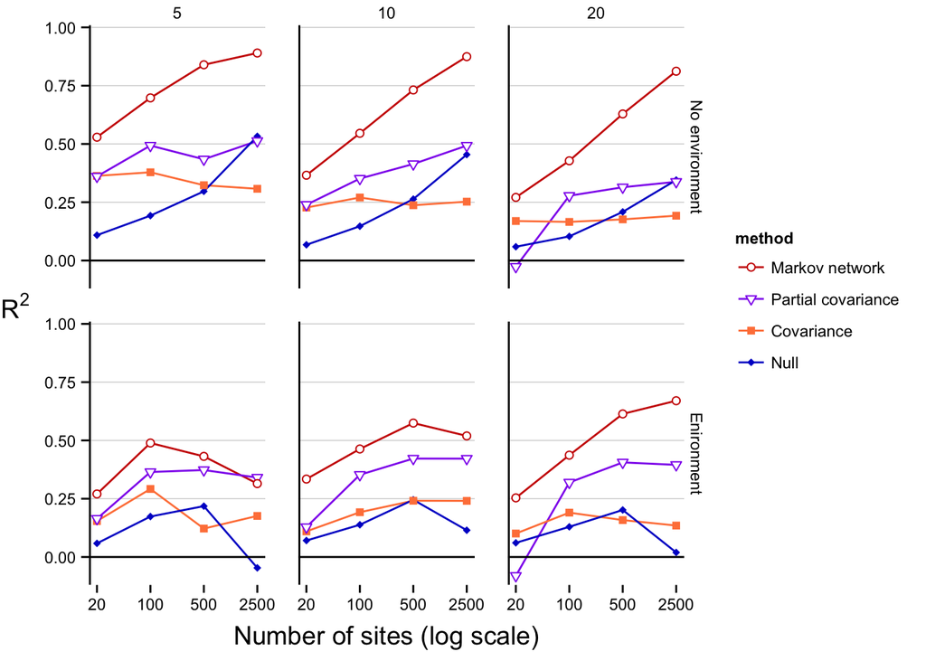

```r
library(ggplot2)

basic_plot = ggplot(aes(n_loc, r2, color = method, shape = method), data = summarized_results) +
  geom_line(size = .5) +
  geom_point(size = 2, fill = "white") +
  facet_grid(env~n_spp) +
  geom_hline(yintercept = 0, size = 1/2) +
  geom_vline(xintercept = 0, size = 1)


scaled_plot = basic_plot +
  scale_shape_manual(values = c(21, 25, 15, 18)) +
  coord_cartesian(ylim = c(-0.12, 1.01)) +
  ylab(expression(R^2)) +
  xlab("Number of sites (log scale)") +
  scale_x_log10(breaks = c(20, 100, 500, 2500), limits = c(20, 2.5E3)) +
  scale_color_manual(values = c("red3", "purple2", "sienna1", "mediumblue"))


scaled_plot + theme_bw(base_size = 11) +
  theme(panel.margin = grid::unit(1.25, "lines")) +
  theme(panel.border = element_blank(), axis.line = element_blank()) +
  theme(
    panel.grid.minor = element_blank(),
    panel.grid.major.y = element_line(color = "lightgray", size = 1/4),
    panel.grid.major.x = element_blank()
  ) +
  theme(strip.background = element_blank(), legend.key = element_blank()) +
  theme(plot.margin = grid::unit(c(.01, .01, .75, .1), "lines")) +
  #theme(legend.text = element_text(size = 11)) +
  theme(
    axis.title.x = element_text(vjust = -0.2, size = 14),
    axis.title.y = element_text(angle = 0, hjust = -.1, size = 14)
  )
```

```r
summarized_results %>% group_by_("method") %>%
  summarize_(~round(mean(r2) * 100))
```

```
## Source: local data frame [4 x 2]
##
##               method round(mean(r2) * 100)
## 1     Markov network                    54
## 2 Partial covariance                    33
## 3         Covariance                    22
## 4               Null                    17
```